# Cardtonic Twitter Sentiment Analysis

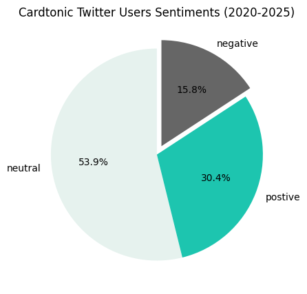

```python
# Plotting a pie chart to show distribution of Sentiments
plt.figure(figsize=[7,5], facecolor='none')
plt.pie(tweets_df['sentiment'].value_counts(), labels=['neutral','postive', "negative"], colors=['#E6f2ee', '#1dc5af', '#666666'], startangle=90, explode= [0,0,0.09], autopct='%1.1f%%');
plt.title('Cardtonic Twitter Users Sentiments (2020-2025)');
```

**Observation**: Between 2020 and 2025, 53.9% of tweets about Cardtonic are neutral, 30.4% are positive, and 15.8% are negative.

### Creating word cloud

```python
stop_words = stopwords.words('english')
stop_words = stop_words + ['u', 'na', 'know', 'one', 'go', 'make', 'see', 'dont', 'amp', 'im', 'cant']
tweets_df['cleaned_words'] = tweets_df['tweet'].astype(str).apply(lambda x: ' '.join([word for word in x.split() if word not in (stop_words)]))
```

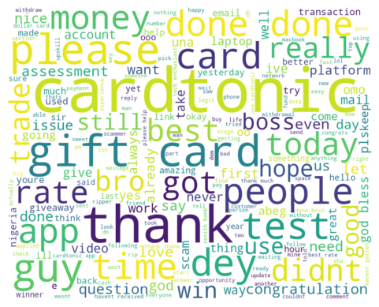

```python
#Creating the text variable
text = " ".join(i for i in tweets_df.cleaned_words)

wc = WordCloud(width = 1000, height = 800, background_color = "white").generate(text)

#Remove axis and display the data as image
plt.axis("off")
plt.imshow(wc, interpolation = "bilinear")
```

**Observation**: The word cloud reveals the most frequent words in the tweets. "Cardtonic" is the subject matter, accompanied by other positive/neutral words such as thank, "gift card," money, people etc.

### Create Average Monthly Sentiment Analysis

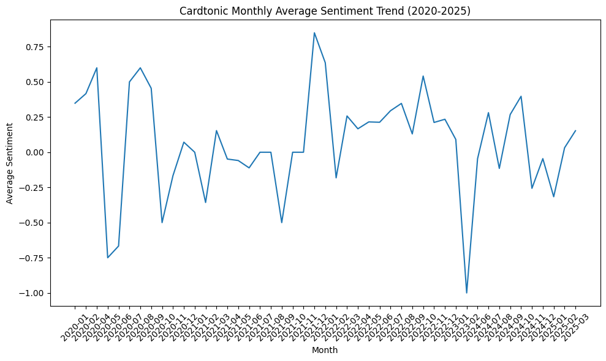

```python
# Extract month-year and group by it

tweets_df["date"] = pd.to_datetime(tweets_df["date"])

# This creates a new column in 'YYYY-MM' format
tweets_df['month_year'] = tweets_df['date'].dt.to_period('M').astype(str)
# Group by month and compute the average sentiment for each month
monthly_sentiment = tweets_df.groupby('month_year')['polarity'].mean().reset_index()

# Create a figure and axis
fig, ax = plt.subplots(figsize=(10, 6))

# Plot the monthly trend using Seaborn
sns.lineplot(data=monthly_sentiment, x='month_year', y='polarity', ax=ax)
plt.title('Cardtonic Monthly Average Sentiment Trend (2020-2025)')
plt.xlabel('Month')
plt.ylabel('Average Sentiment')

plt.xticks(rotation=45)  # Rotate x labels for readability
plt.tight_layout()      # Adjust layout if necessary
plt.show()
```

### The top issues customers face (e.g., transaction failures, limits, blocked cards)

```python
negative_df = tweets_df[tweets_df['sentiment'] == 'negative']
```

```python
# Set the max column width to None to display the full text
pd.set_option('display.max_colwidth', None)

negative_df[['sentiment','confidence','tweet']].head()
```

|  | sentiment | confidence | tweet |
| --- | --- | --- | --- |
| 41 | negative | 0.492145 | it is better you reply my dm before i send proof to verydarkman and get justice and nigeria will stop trading with you |
| 42 | negative | 0.934781 | you guys ripped me |
| 44 | negative | 0.526989 | there rates are way better than infact i had to deactivate and delete the chipper app greedy bastards |
| 47 | negative | 0.536261 | you guys should work on your app ona dey take forever to pay and e no sharp |
| 49 | negative | 0.897855 | theyre very slow in trading and payments |

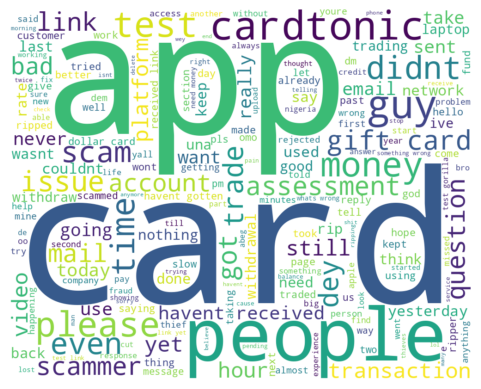

```python
#Creating the text variable
text = " ".join(i for i in negative_df.cleaned_words)

wc = WordCloud(width = 1000, height = 800, background_color = "white").generate(text)

#Remove axis and display the data as image
plt.axis("off")
plt.imshow(wc, interpolation = "bilinear")
```

**Observation**: A significant number of negative tweets highlight issues with the app, card, account, and timing. This suggests that the app needs a thorough evaluation and subsequent updates to enhance the user experience. Also, the sales and customer service teams must respond promptly to customer concerns. Negative remarks featuring words such as "scam," "scammer," or "bad" should be addressed immediately to restore customer confidence in Cardtonic.

### Cardtonic common positive themes

```python
positive_df = tweets_df[tweets_df['sentiment'] == 'positive']
```

```python
positive_df[['sentiment','confidence','tweet']].head()
```

|  | sentiment | confidence | tweet |
| --- | --- | --- | --- |
| 0 | positive | 0.793052 | let your face shine upon me |
| 5 | positive | 0.952267 | god bless you abundantly sir |
| 7 | positive | 0.970248 | cardtonic is great |
| 8 | positive | 0.872880 | stay blessed |
| 9 | positive | 0.817794 | wowamazing |

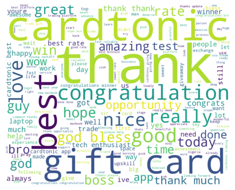

```python
#Creating the text variable
text = " ".join(i for i in positive_df.cleaned_words)

wc = WordCloud(width = 1000, height = 800, background_color = "white").generate(text)

#Remove axis and display the data as image
plt.axis("off")
plt.imshow(wc, interpolation = "bilinear")
```

**Observation:** Most of positive tweets made reference to the Appreciative words like thank, best, congratulations. This might be influenced by Customer reward programs, excellent customer service, promotional giveaway, etc